# Untitled

ryotoitoi

2022-05-14

# Library

```r
library(tidyverse)
library(purrr)
library(data.table)
library(scales)
library(patchwork)
library(lemon)
library(lubridate)
library(magick)
```

```r
#ggplot setting
theme_set(theme_minimal() +
         theme(plot.title = element_text(size = 9, face = "bold"),
               plot.subtitle = element_text(size  = 9, face = "bold"),
               axis.text.x = element_text(size = 9),
               axis.text.y = element_text(size = 9),
               axis.title.x = element_text(size = 9),
               axis.title.y = element_text(size = 9),
               legend.text = element_text(size = 9),
               legend.title = element_text(size = 9),
               strip.text.x = element_text(size = 9)
              )
          )

#Choose your favorite color
mycol = c("turquoise", "lightslateblue","lightskyblue",
          "chartreuse2", "palegreen2", "mistyrose2", "grey60", "hotpink1")
```

# Data Files

- There seems to be “stock_list” file on the level above the training data.
- “stock_file” probably contains information on stocks in the Tokyo market.

```r
data_path = "../"
train_path = paste0(data_path, "train_files/")
cat("list of the top directory\n")
```

```
## list of the top directory
```

```r
list.files(data_path, full.names = T)
```

```
## [1] "..//data_specifications" "..//eda"
## [3] "..//example_test_files"  "..//jpx.Rproj"
## [5] "..//README.md"           "..//stock_list.csv"
## [7] "..//supplemental_files"  "..//train_files"
```

```r
cat("training data\n")
```

```
## training data
```

```r
list.files(train_path, full.names = T)
```

```
## [1] "../train_files//financials.csv"
## [2] "../train_files//options.csv"
## [3] "../train_files//secondary_stock_prices.csv"
## [4] "../train_files//stock_prices.csv"
## [5] "../train_files//trades.csv"
```

```r
stock_list <- fread(
  paste0(data_path, "stock_list.csv"),na.strings = c("","NULL")
  )
stock_list %>% head()
```

```
##    SecuritiesCode EffectiveDate
## 1:           1301      20211230
## 2:           1305      20211230
## 3:           1306      20211230
## 4:           1308      20211230
## 5:           1309      20211230
## 6:           1311      20211230
##                                                    Name
## 1:                                     KYOKUYO CO.,LTD.
## 2:                                      Daiwa ETF-TOPIX
## 3:                NEXT FUNDS TOPIX Exchange Traded Fund
## 4:               Nikko Exchange Traded Index Fund TOPIX
## 5: NEXT FUNDS ChinaAMC SSE50 Index Exchange Traded Fund
## 6:        NEXT FUNDS TOPIX Core 30 Exchange Traded Fund
##            Section/Products NewMarketSegment 33SectorCode
```

[output cut: 27 more lines]

```r
stock_list %>% tail()
```

```
##    SecuritiesCode EffectiveDate                                   Name
## 1:           9993      20211230                      YAMAZAWA CO.,LTD.
## 2:           9994      20211230                     YAMAYA CORPORATION
## 3:           9995      20211230                        GLOSEL Co.,Ltd.
## 4:           9996      20211230                         Satoh&Co.,Ltd.
## 5:           9997      20211230                       BELLUNA CO.,LTD.
## 6:          25935      20211230 ITO EN,LTD.(shares of preferred stock)
##               Section/Products NewMarketSegment 33SectorCode    33SectorName
## 1:    First Section (Domestic)  Standard Market         6100    Retail Trade
## 2:    First Section (Domestic)  Standard Market         6100    Retail Trade
## 3:    First Section (Domestic)     Prime Market         6050 Wholesale Trade
## 4: JASDAQ(Standard / Domestic)  Standard Market         6050 Wholesale Trade
## 5:    First Section (Domestic)     Prime Market         6100    Retail Trade
## 6:    First Section (Domestic)             <NA>         3050           Foods
##    17SectorCode                 17SectorName NewIndexSeriesSizeCode
```

[output cut: 20 more lines]

```r
cat(paste0(train_path, "stock_prices.csv"))
```

```
## ../train_files/stock_prices.csv
```

```r
stock_price <- fread(
  paste0(train_path, "stock_prices.csv"), na.strings = c("", "NULL")
)
stock_price %>% head()
```

```
##            RowId       Date SecuritiesCode Open High  Low Close  Volume
## 1: 20170104_1301 2017-01-04           1301 2734 2755 2730  2742   31400
## 2: 20170104_1332 2017-01-04           1332  568  576  563   571 2798500
## 3: 20170104_1333 2017-01-04           1333 3150 3210 3140  3210  270800
## 4: 20170104_1376 2017-01-04           1376 1510 1550 1510  1550   11300
## 5: 20170104_1377 2017-01-04           1377 3270 3350 3270  3330  150800
## 6: 20170104_1379 2017-01-04           1379 2105 2147 2101  2143   77300
##    AdjustmentFactor ExpectedDividend SupervisionFlag       Target
## 1:                1               NA           FALSE 0.0007304602
## 2:                1               NA           FALSE 0.0123239437
## 3:                1               NA           FALSE 0.0061538462
## 4:                1               NA           FALSE 0.0110533160
## 5:                1               NA           FALSE 0.0030257186
## 6:                1               NA           FALSE 0.0051691729
```

```r
financials <- fread(
  paste0(train_path, "financials.csv"), na.strings = c("", "NULL")
)
financials %>% head()
```

```
##    DisclosureNumber      DateCode       Date SecuritiesCode DisclosedDate
## 1:     2.016121e+13 20170104_2753 2017-01-04           2753    2017-01-04
## 2:     2.017010e+13 20170104_3353 2017-01-04           3353    2017-01-04
## 3:     2.016123e+13 20170104_4575 2017-01-04           4575    2017-01-04
## 4:     2.017010e+13 20170105_2659 2017-01-05           2659    2017-01-05
## 5:     2.017011e+13 20170105_3050 2017-01-05           3050    2017-01-05
## 6:     2.016123e+13 20170105_3139 2017-01-05           3139    2017-01-05
##    DisclosedTime DisclosedUnixTime                        TypeOfDocument
## 1:      07:30:00        1483482600 3QFinancialStatements_Consolidated_JP
## 2:      15:00:00        1483509600 3QFinancialStatements_Consolidated_JP
## 3:      12:00:00        1483498800                      ForecastRevision
## 4:      15:00:00        1483596000 3QFinancialStatements_Consolidated_JP
## 5:      15:30:00        1483597800                      ForecastRevision
## 6:      15:30:00        1483597800                      ForecastRevision
##    CurrentPeriodEndDate TypeOfCurrentPeriod CurrentFiscalYearStartDate
```

[output cut: 111 more lines]

# stock_list

**This is assumed to be information on all issues in the Tokyo market.**

I should check the columns name.

```r
stock_list %>% names()
```

```
##  [1] "SecuritiesCode"         "EffectiveDate"          "Name"
##  [4] "Section/Products"       "NewMarketSegment"       "33SectorCode"
##  [7] "33SectorName"           "17SectorCode"           "17SectorName"
## [10] "NewIndexSeriesSizeCode" "NewIndexSeriesSize"     "TradeDate"
## [13] "Close"                  "IssuedShares"           "MarketCapitalization"
## [16] "Universe0"
```

```r
stock_list %>% str()
```

```
## Classes 'data.table' and 'data.frame':   4417 obs. of  16 variables:
##  $ SecuritiesCode        : int  1301 1305 1306 1308 1309 1311 1312 1313 1319 1320 ...
##  $ EffectiveDate         : int  20211230 20211230 20211230 20211230 20211230 20211230 20211230 20211230 20211230 20211230 ...
##  $ Name                  : chr  "KYOKUYO CO.,LTD." "Daiwa ETF-TOPIX" "NEXT FUNDS TOPIX Exchange Traded Fund" "Nikko Exchange Traded Index Fund TOPIX" ...
##  $ Section/Products      : chr  "First Section (Domestic)" "ETFs/ ETNs" "ETFs/ ETNs" "ETFs/ ETNs" ...
##  $ NewMarketSegment      : chr  "Prime Market" NA NA NA ...
##  $ 33SectorCode          : chr  "50" "-" "-" "-" ...
##  $ 33SectorName          : chr  "Fishery, Agriculture and Forestry" "-" "-" "-" ...
##  $ 17SectorCode          : chr  "1" "-" "-" "-" ...
##  $ 17SectorName          : chr  "FOODS" "-" "-" "-" ...
##  $ NewIndexSeriesSizeCode: chr  "7" "-" "-" "-" ...
##  $ NewIndexSeriesSize    : chr  "TOPIX Small 2" "-" "-" "-" ...
##  $ TradeDate             : num  20211230 20211230 20211230 20211230 20211230 ...
##  $ Close                 : num  3080 2097 2074 2053 44280 ...
##  $ IssuedShares          : num  1.09e+07 3.63e+09 7.92e+09 3.74e+09 7.26e+04 ...
##  $ MarketCapitalization  : num  3.37e+10 7.62e+12 1.64e+13 7.67e+12 3.22e+09 ...
##  $ Universe0             : logi  TRUE FALSE FALSE FALSE FALSE FALSE ...
##  - attr(*, ".internal.selfref")=<externalptr>
```

```r
st1 <- names(stock_list)[str_detect(names(stock_list), "^[0-9]")] # detect col names which start with figure
print(st1)
```

```
## [1] "33SectorCode" "33SectorName" "17SectorCode" "17SectorName"
```

```r
st2 <- c("SectorCode_33", "SectorName_33", "SectorCode_17", "SectorName_17")
setnames(stock_list, st1, st2) # replace col name st1 to st2


st1 <- names(stock_list)[str_detect(names(stock_list), "/")] %>%
  str_replace_all("/", "_")

setnames(stock_list, names(stock_list)[str_detect(names(stock_list), "/")], st1)

glimpse(stock_list)
```

```
## Rows: 4,417
## Columns: 16
## $ SecuritiesCode         <int> 1301, 1305, 1306, 1308, 1309, 1311, 1312, 1313,…
## $ EffectiveDate          <int> 20211230, 20211230, 20211230, 20211230, 2021123…
## $ Name                   <chr> "KYOKUYO CO.,LTD.", "Daiwa ETF-TOPIX", "NEXT FU…
## $ Section_Products       <chr> "First Section (Domestic)", "ETFs/ ETNs", "ETFs…
## $ NewMarketSegment       <chr> "Prime Market", NA, NA, NA, NA, NA, NA, NA, NA,…
## $ SectorCode_33          <chr> "50", "-", "-", "-", "-", "-", "-", "-", "-", "…
## $ SectorName_33          <chr> "Fishery, Agriculture and Forestry", "-", "-", …
## $ SectorCode_17          <chr> "1", "-", "-", "-", "-", "-", "-", "-", "-", "-…
## $ SectorName_17          <chr> "FOODS", "-", "-", "-", "-", "-", "-", "-", "-"…
## $ NewIndexSeriesSizeCode <chr> "7", "-", "-", "-", "-", "-", "-", "-", "-", "-…
## $ NewIndexSeriesSize     <chr> "TOPIX Small 2", "-", "-", "-", "-", "-", "-", …
## $ TradeDate              <dbl> 20211230, 20211230, 20211230, 20211230, 2021123…
## $ Close                  <dbl> 3080.0, 2097.0, 2073.5, 2053.0, 44280.0, 1025.0…
## $ IssuedShares           <dbl> 10928283, 3634635625, 7917718452, 3736943486, 7…
## $ MarketCapitalization   <dbl> 3.365911e+10, 7.621831e+12, 1.641739e+13, 7.671…
## $ Universe0              <lgl> TRUE, FALSE, FALSE, FALSE, FALSE, FALSE, FALSE,…
```

```r
?glimpse
```

```
## Help on topic 'glimpse' was found in the following packages:
##
##   Package               Library
##   pillar                /Library/Frameworks/R.framework/Versions/4.1/Resources/library
##   dplyr                 /Library/Frameworks/R.framework/Versions/4.1/Resources/library
##   tibble                /Library/Frameworks/R.framework/Versions/4.1/Resources/library
##
##
## Using the first match ...
```

## Generate the list of unique_values

```r
sapply(stock_list, function(x){length(unique(x))}) %>%
  data.table(colname = names(.), unique_values = .)
```

```
##                    colname unique_values
##  1:         SecuritiesCode          4417
##  2:          EffectiveDate            10
##  3:                   Name          4411
##  4:       Section_Products            11
##  5:       NewMarketSegment             7
##  6:          SectorCode_33            34
##  7:          SectorName_33            34
##  8:          SectorCode_17            18
##  9:          SectorName_17            19
## 10: NewIndexSeriesSizeCode             6
## 11:     NewIndexSeriesSize             6
## 12:              TradeDate            11
## 13:                  Close          2567
## 14:           IssuedShares          4012
## 15:   MarketCapitalization          4122
## 16:              Universe0             2
```

**A brief comparsion of old and new market segments.**

```r
stock_list[, n:= 1:.N, by= Section_Products]
stock_list
```

```
##       SecuritiesCode EffectiveDate
##    1:           1301      20211230
##    2:           1305      20211230
##    3:           1306      20211230
##    4:           1308      20211230
##    5:           1309      20211230
##   ---
## 4413:           9994      20211230
## 4414:           9995      20211230
## 4415:           9996      20211230
## 4416:           9997      20211230
## 4417:          25935      20211230
##                                                       Name
##    1:                                     KYOKUYO CO.,LTD.
##    2:                                      Daiwa ETF-TOPIX
```

[output cut: 57 more lines]

```r
stock_list[n ==1] %>%
  select(Section_Products, NewMarketSegment)
```

```
##                                                Section_Products
##  1:                                    First Section (Domestic)
##  2:                                                  ETFs/ ETNs
##  3:                                 JASDAQ(Standard / Domestic)
##  4:                                     JASDAQ(Growth/Domestic)
##  5:                                          Mothers (Domestic)
##  6:                                    Second Section(Domestic)
##  7:                                     First Section (Foreign)
##  8: REIT, Venture Funds, Country Funds and Infrastructure Funds
##  9:                                  JASDAQ(Standard / Foreign)
## 10:                                           Mothers (Foreign)
## 11:                                     Second Section(Foreign)
##                    NewMarketSegment
##  1:                    Prime Market
##  2:                            <NA>
##  3:                 Standard Market
##  4:                   Growth Market
##  5:                   Growth Market
##  6:                 Standard Market
##  7:    Prime Market (Foreign Stock)
##  8:                            <NA>
##  9: Standard Market (Foreign Stock)
## 10:   Growth Market (Foreign Stock)
## 11: Standard Market (Foreign Stock)
```

- The new segments(4/4/2022~) seems simpler and easier to understand.

# Stock Price

```r
glimpse(stock_price)
```

```
## Rows: 2,332,531
## Columns: 12
## $ RowId            <chr> "20170104_1301", "20170104_1332", "20170104_1333", "2…
## $ Date             <date> 2017-01-04, 2017-01-04, 2017-01-04, 2017-01-04, 2017…
## $ SecuritiesCode   <int> 1301, 1332, 1333, 1376, 1377, 1379, 1381, 1407, 1414,…
## $ Open             <dbl> 2734.0, 568.0, 3150.0, 1510.0, 3270.0, 2105.0, 1950.0…
## $ High             <dbl> 2755, 576, 3210, 1550, 3350, 2147, 1960, 877, 5060, 1…
## $ Low              <dbl> 2730, 563, 3140, 1510, 3270, 2101, 1949, 851, 4935, 1…
## $ Close            <dbl> 2742, 571, 3210, 1550, 3330, 2143, 1960, 866, 5050, 1…
## $ Volume           <int> 31400, 2798500, 270800, 11300, 150800, 77300, 1300, 1…
## $ AdjustmentFactor <dbl> 1, 1, 1, 1, 1, 1, 1, 1, 1, 1, 1, 1, 1, 1, 1, 1, 1, 1,…
## $ ExpectedDividend <dbl> NA, NA, NA, NA, NA, NA, NA, NA, NA, NA, NA, NA, NA, N…
## $ SupervisionFlag  <lgl> FALSE, FALSE, FALSE, FALSE, FALSE, FALSE, FALSE, FALS…
## $ Target           <dbl> 0.0007304602, 0.0123239437, 0.0061538462, 0.011053316…
```

- This appears to be a pure record of price movement.
- What is “target” ??

**How many stocks should we forecast?**

```r
stock_price %>%
  select(SecuritiesCode) %>%
  unique() %>%
  nrow()
```

```
## [1] 2000
```

- The forecast covers 2,000 stocks out of 4,417 stocks.

## Date period

```r
stock_price %>%
  mutate(., Date = as.IDate(Date))
```

```
##                  RowId       Date SecuritiesCode Open High  Low Close  Volume
##       1: 20170104_1301 2017-01-04           1301 2734 2755 2730  2742   31400
##       2: 20170104_1332 2017-01-04           1332  568  576  563   571 2798500
##       3: 20170104_1333 2017-01-04           1333 3150 3210 3140  3210  270800
##       4: 20170104_1376 2017-01-04           1376 1510 1550 1510  1550   11300
##       5: 20170104_1377 2017-01-04           1377 3270 3350 3270  3330  150800
##      ---
## 2332527: 20211203_9990 2021-12-03           9990  514  528  513   528   44200
## 2332528: 20211203_9991 2021-12-03           9991  782  794  782   794   35900
## 2332529: 20211203_9993 2021-12-03           9993 1690 1690 1645  1645    7200
## 2332530: 20211203_9994 2021-12-03           9994 2388 2396 2380  2389    6500
## 2332531: 20211203_9997 2021-12-03           9997  690  711  686   696  381100
##          AdjustmentFactor ExpectedDividend SupervisionFlag        Target
##       1:                1               NA           FALSE  0.0007304602
##       2:                1               NA           FALSE  0.0123239437
##       3:                1               NA           FALSE  0.0061538462
##       4:                1               NA           FALSE  0.0110533160
##       5:                1               NA           FALSE  0.0030257186
##      ---
## 2332527:                1               NA           FALSE  0.0348162476
## 2332528:                1               NA           FALSE  0.0254777070
## 2332529:                1               NA           FALSE -0.0043023970
## 2332530:                1               NA           FALSE  0.0090984285
## 2332531:                1               NA           FALSE  0.0184135977
```

```r
range(stock_price$Date)
```

```
## [1] "2017-01-04" "2021-12-03"
```

- All data are from the market classification (Section_Products).

# financials

```r
glimpse(financials)
```

```
## Rows: 92,956
## Columns: 45
## $ DisclosureNumber                                                             <dbl> …
## $ DateCode                                                                     <chr> …
## $ Date                                                                         <date> …
## $ SecuritiesCode                                                               <dbl> …
## $ DisclosedDate                                                                <date> …
## $ DisclosedTime                                                                <chr> …
## $ DisclosedUnixTime                                                            <dbl> …
## $ TypeOfDocument                                                               <chr> …
## $ CurrentPeriodEndDate                                                         <date> …
## $ TypeOfCurrentPeriod                                                          <chr> …
## $ CurrentFiscalYearStartDate                                                   <date> …
## $ CurrentFiscalYearEndDate                                                     <date> …
## $ NetSales                                                                     <chr> …
```

[output cut: 32 more lines]

**Convert some strings into numerical.** **Corrects time data to iTime**

```r
cols <- names(financials)[c(13:36, 43:45)]
financials[, (cols) := lapply(.SD, as.numeric), .SDcols = cols] # .SD is "Self-reference of the Data"
```

[output not shown]

```r
financials$DisclosedTime <- as.ITime(financials$DisclosedTime)
```

```r
glimpse(financials)
```

```
## Rows: 92,956
## Columns: 45
## $ DisclosureNumber                                                             <dbl> …
## $ DateCode                                                                     <chr> …
## $ Date                                                                         <date> …
## $ SecuritiesCode                                                               <dbl> …
## $ DisclosedDate                                                                <date> …
## $ DisclosedTime                                                                <ITime> …
## $ DisclosedUnixTime                                                            <dbl> …
## $ TypeOfDocument                                                               <chr> …
## $ CurrentPeriodEndDate                                                         <date> …
## $ TypeOfCurrentPeriod                                                          <chr> …
## $ CurrentFiscalYearStartDate                                                   <date> …
## $ CurrentFiscalYearEndDate                                                     <date> …
## $ NetSales                                                                     <dbl> …
```

[output cut: 32 more lines]

# Check for unique value and NA.

```r
df_tmp <- financials %>%
  sapply(function(x){length(unique(x))}) %>%
  data.table(feature = names(.), unique_values = .)

df_tmp2 <- colSums(sapply(financials, is.na)) %>%
  data.table(feature = names(.), NAs = .)

df_tmp
```

```
##                                                                          feature
##  1:                                                             DisclosureNumber
##  2:                                                                     DateCode
##  3:                                                                         Date
##  4:                                                               SecuritiesCode
##  5:                                                                DisclosedDate
##  6:                                                                DisclosedTime
##  7:                                                            DisclosedUnixTime
##  8:                                                               TypeOfDocument
##  9:                                                         CurrentPeriodEndDate
## 10:                                                          TypeOfCurrentPeriod
## 11:                                                   CurrentFiscalYearStartDate
## 12:                                                     CurrentFiscalYearEndDate
## 13:                                                                     NetSales
## 14:                                                              OperatingProfit
```

[output cut: 79 more lines]

```r
df_tmp2
```

```
##                                                                          feature
##  1:                                                             DisclosureNumber
##  2:                                                                     DateCode
##  3:                                                                         Date
##  4:                                                               SecuritiesCode
##  5:                                                                DisclosedDate
##  6:                                                                DisclosedTime
##  7:                                                            DisclosedUnixTime
##  8:                                                               TypeOfDocument
##  9:                                                         CurrentPeriodEndDate
## 10:                                                          TypeOfCurrentPeriod
## 11:                                                   CurrentFiscalYearStartDate
## 12:                                                     CurrentFiscalYearEndDate
## 13:                                                                     NetSales
## 14:                                                              OperatingProfit
```

[output cut: 79 more lines]

```r
cat("nrow = ", nrow(financials))
```

```
## nrow =  92956
```

```r
df_tmp <- df_tmp %>%
  left_join(df_tmp2, by = "feature") %>%
  mutate(ColNo = row_number())
df_tmp
```

```
##                                                                          feature
##  1:                                                             DisclosureNumber
##  2:                                                                     DateCode
##  3:                                                                         Date
##  4:                                                               SecuritiesCode
##  5:                                                                DisclosedDate
##  6:                                                                DisclosedTime
##  7:                                                            DisclosedUnixTime
##  8:                                                               TypeOfDocument
##  9:                                                         CurrentPeriodEndDate
## 10:                                                          TypeOfCurrentPeriod
## 11:                                                   CurrentFiscalYearStartDate
## 12:                                                     CurrentFiscalYearEndDate
## 13:                                                                     NetSales
## 14:                                                              OperatingProfit
```

[output cut: 79 more lines]

```r
view(df_tmp)
```

**The following may be paticularly relevant to stock price movements in this context.**

1. EaringsPerShare:一株当たり利益
2. ForecastEarningsPerShare:予測一株当たり利益
3. DisclosedDate:開示日
- If the expected earings per share is higher than the previous period, the stock price may rise in the future. Unfortunately, there seems to be a lot of NA.
- Price movements are expected to be large on the disclosure date.

**The stock market closes at 3:00 p.m.** We believe that earnings disclosure after 3:00 p.m. has a greater impact on price movements the next day than on that day. For this reason, I will move the disclosure date by one day for earnings discoosures after 3:00 p.m.

```r
financials %>%
  mutate(
    DisclosedDate = if_else(
      DisclosedTime>=as.ITime("15:00:00"), DisclosedDate + 1, DisclosedDate
      )
    )
```

```
##        DisclosureNumber      DateCode       Date SecuritiesCode DisclosedDate
##     1:     2.016121e+13 20170104_2753 2017-01-04           2753    2017-01-04
##     2:     2.017010e+13 20170104_3353 2017-01-04           3353    2017-01-05
##     3:     2.016123e+13 20170104_4575 2017-01-04           4575    2017-01-04
##     4:     2.017010e+13 20170105_2659 2017-01-05           2659    2017-01-06
##     5:     2.017011e+13 20170105_3050 2017-01-05           3050    2017-01-06
##    ---
## 92952:     2.021112e+13 20211203_6040 2021-12-03           6040    2021-12-04
## 92953:     2.021120e+13 20211203_6898 2021-12-03           6898    2021-12-04
## 92954:     2.021120e+13 20211203_6969 2021-12-03           6969    2021-12-04
## 92955:     2.021112e+13 20211203_8057 2021-12-03           8057    2021-12-04
## 92956:     2.021120e+13 20211203_9627 2021-12-03           9627    2021-12-04
##        DisclosedTime DisclosedUnixTime                        TypeOfDocument
##     1:      07:30:00        1483482600 3QFinancialStatements_Consolidated_JP
##     2:      15:00:00        1483509600 3QFinancialStatements_Consolidated_JP
```

[output cut: 213 more lines]

**rename columns**

```r
financials %>%
  setnames(names(financials)[43], "NumberOfIssued")
financials %>% names()
```

```
##  [1] "DisclosureNumber"
##  [2] "DateCode"
##  [3] "Date"
##  [4] "SecuritiesCode"
##  [5] "DisclosedDate"
##  [6] "DisclosedTime"
##  [7] "DisclosedUnixTime"
##  [8] "TypeOfDocument"
##  [9] "CurrentPeriodEndDate"
## [10] "TypeOfCurrentPeriod"
## [11] "CurrentFiscalYearStartDate"
## [12] "CurrentFiscalYearEndDate"
## [13] "NetSales"
## [14] "OperatingProfit"
## [15] "OrdinaryProfit"
```

[output cut: 30 more lines]

**Consider missing value completion for ForecastEarningsPerShare.** I believe earnings per share can be obtained by dividing earnings by the number of shares outstanding.

```r
financials <- financials %>%
  mutate(ForecastEarningsPerShare2 = round(ForecastProfit / NumberOfIssued ,  digits = 1))

financials %>%
  names()
```

```
##  [1] "DisclosureNumber"
##  [2] "DateCode"
##  [3] "Date"
##  [4] "SecuritiesCode"
##  [5] "DisclosedDate"
##  [6] "DisclosedTime"
##  [7] "DisclosedUnixTime"
##  [8] "TypeOfDocument"
##  [9] "CurrentPeriodEndDate"
## [10] "TypeOfCurrentPeriod"
## [11] "CurrentFiscalYearStartDate"
## [12] "CurrentFiscalYearEndDate"
## [13] "NetSales"
## [14] "OperatingProfit"
## [15] "OrdinaryProfit"
```

[output cut: 31 more lines]

**Check to see if the value is available.**

```r
financials %>%
  select(ForecastEarningsPerShare, ForecastEarningsPerShare2) %>%
  head(20)
```

```
##     ForecastEarningsPerShare ForecastEarningsPerShare2
##  1:                   319.76                     319.8
##  2:                   485.36                     457.0
##  3:                   -93.11                        NA
##  4:                   285.05                     284.9
##  5:                       NA                        NA
##  6:                   173.43                        NA
##  7:                  4558.00                        NA
##  8:                    47.70                      44.8
##  9:                   -47.37                        NA
## 10:                   913.28                     865.4
## 11:                   110.87                      81.8
## 12:                    36.55                        NA
## 13:                    19.02                      16.8
## 14:                   186.87                        NA
## 15:                   221.51                     219.6
## 16:                   276.91                     276.9
## 17:                   133.17                     120.0
## 18:                   125.20                     124.9
## 19:                       NA                        NA
## 20:                    68.83                      68.8
```

```r
financials %>%
  filter(!is.na(ForecastEarningsPerShare2) & is.na(ForecastEarningsPerShare)) %>%
  nrow()
```

```
## [1] 846
```

- 846 cases could be completed. It is not so much, but I will interpolate.

```r
financials <- financials %>%
  mutate(
    ForecastEarningsPerShare = if_else(is.na(ForecastEarningsPerShare),
                                       ForecastEarningsPerShare2,
                                       ForecastEarningsPerShare)
  )

financials %>%
  filter(!is.na(ForecastEarningsPerShare2) & is.na(ForecastEarningsPerShare)) %>%
  nrow()
```

```
## [1] 0
```

**Create Disclosed(1 or 0) when I combine them later.**

```r
financials <- financials %>%
  mutate(disclosed = 1)
financials %>% select(disclosed)
```

```
##        disclosed
##     1:         1
##     2:         1
##     3:         1
##     4:         1
##     5:         1
##    ---
## 92952:         1
## 92953:         1
## 92954:         1
## 92955:         1
## 92956:         1
```

# Combining Data Sets

Let’s combine the stock price data set with stock information and financial performance information.

```r
stock_list
```

```
##       SecuritiesCode EffectiveDate
##    1:           1301      20211230
##    2:           1305      20211230
##    3:           1306      20211230
##    4:           1308      20211230
##    5:           1309      20211230
##   ---
## 4413:           9994      20211230
## 4414:           9995      20211230
## 4415:           9996      20211230
## 4416:           9997      20211230
## 4417:          25935      20211230
##                                                       Name
##    1:                                     KYOKUYO CO.,LTD.
##    2:                                      Daiwa ETF-TOPIX
```

[output cut: 57 more lines]

```r
df_comb <- stock_price %>%
  left_join(stock_list %>% select(1,3:9), by = "SecuritiesCode") # conbine stock_price with stock_list
```

```r
df_comb <- df_comb %>%
  left_join(
  financials %>% select(DisclosedDate, SecuritiesCode, EarningsPerShare, ForecastEarningsPerShare, disclosed) %>% rename(Date = DisclosedDate),
  by = c("Date", "SecuritiesCode")
  )

df_comb
```

```
##                  RowId       Date SecuritiesCode Open High  Low Close  Volume
##       1: 20170104_1301 2017-01-04           1301 2734 2755 2730  2742   31400
##       2: 20170104_1332 2017-01-04           1332  568  576  563   571 2798500
##       3: 20170104_1333 2017-01-04           1333 3150 3210 3140  3210  270800
##       4: 20170104_1376 2017-01-04           1376 1510 1550 1510  1550   11300
##       5: 20170104_1377 2017-01-04           1377 3270 3350 3270  3330  150800
##      ---
## 2335591: 20211203_9990 2021-12-03           9990  514  528  513   528   44200
## 2335592: 20211203_9991 2021-12-03           9991  782  794  782   794   35900
## 2335593: 20211203_9993 2021-12-03           9993 1690 1690 1645  1645    7200
## 2335594: 20211203_9994 2021-12-03           9994 2388 2396 2380  2389    6500
## 2335595: 20211203_9997 2021-12-03           9997  690  711  686   696  381100
##          AdjustmentFactor ExpectedDividend SupervisionFlag        Target
##       1:                1               NA           FALSE  0.0007304602
##       2:                1               NA           FALSE  0.0123239437
```

[output cut: 57 more lines]

```r
df_comb <- df_comb %>%
  mutate(
    disclosed = if_else(
    is.na(disclosed),
    0,
    disclosed
    )
  )

df_comb %>% head(10)
```

```
##             RowId       Date SecuritiesCode Open High  Low Close  Volume
##  1: 20170104_1301 2017-01-04           1301 2734 2755 2730  2742   31400
##  2: 20170104_1332 2017-01-04           1332  568  576  563   571 2798500
##  3: 20170104_1333 2017-01-04           1333 3150 3210 3140  3210  270800
##  4: 20170104_1376 2017-01-04           1376 1510 1550 1510  1550   11300
##  5: 20170104_1377 2017-01-04           1377 3270 3350 3270  3330  150800
##  6: 20170104_1379 2017-01-04           1379 2105 2147 2101  2143   77300
##  7: 20170104_1381 2017-01-04           1381 1950 1960 1949  1960    1300
##  8: 20170104_1407 2017-01-04           1407  857  877  851   866  147000
##  9: 20170104_1414 2017-01-04           1414 4940 5060 4935  5050  119600
## 10: 20170104_1417 2017-01-04           1417 1051 1063 1048  1053  347500
##     AdjustmentFactor ExpectedDividend SupervisionFlag        Target
##  1:                1               NA           FALSE  0.0007304602
##  2:                1               NA           FALSE  0.0123239437
##  3:                1               NA           FALSE  0.0061538462
```

[output cut: 51 more lines]

```r
df_stock_list_count <- stock_list %>%
  count(NewMarketSegment) %>%
  arrange(desc(n)) %>%
  rename(stock_list = n)

df_stock_list_count
```

```
##                   NewMarketSegment stock_list
## 1:                    Prime Market       1839
## 2:                 Standard Market       1466
## 3:                            <NA>        645
## 4:                   Growth Market        461
## 5:   Growth Market (Foreign Stock)          3
## 6: Standard Market (Foreign Stock)          2
## 7:    Prime Market (Foreign Stock)          1
```

```r
df_stock_price_count <- df_comb %>%
  group_by(NewMarketSegment, SecuritiesCode) %>%
  count() %>%
  group_by(NewMarketSegment) %>%
  count() %>%
  rename(stock_price = n)

df_stock_price_count
```

```
## # A tibble: 3 × 2
## # Groups:   NewMarketSegment [3]
##   NewMarketSegment stock_price
##   <chr>                  <int>
## 1 Growth Market             92
## 2 Prime Market            1623
## 3 Standard Market          285
```

```r
df_tmp <- left_join(df_stock_list_count, df_stock_price_count, by = "NewMarketSegment")
df_tmp %>%
  mutate(rate = round(stock_price/stock_list, digits = 2))
```

```
##                   NewMarketSegment stock_list stock_price rate
## 1:                    Prime Market       1839        1623 0.88
## 2:                 Standard Market       1466         285 0.19
## 3:                            <NA>        645          NA   NA
## 4:                   Growth Market        461          92 0.20
## 5:   Growth Market (Foreign Stock)          3          NA   NA
## 6: Standard Market (Foreign Stock)          2          NA   NA
## 7:    Prime Market (Foreign Stock)          1          NA   NA
```

- It appears that about 90% of the current prime market and 20% of remaining market issues are covered.

```r
options(repr.plot.width = 15, repr.plot.height = 8)

df_stock_list_sector <- stock_list %>%
  group_by(SectorName_33, SecuritiesCode) %>%
  summarise(n = n()) %>%
  group_by(SectorName_33) %>%
  summarise(n = n()) %>%
  arrange(desc(n)) %>%
  ungroup()
df_stock_list_sector
```

```
## # A tibble: 34 × 2
##    SectorName_33                   n
##    <chr>                       <int>
##  1 Information & Communication   551
##  2 Services                      521
##  3 -                             500
##  4 Retail Trade                  359
##  5 Wholesale Trade               320
##  6 Electric Appliances           255
##  7 Machinery                     230
##  8 Chemicals                     218
##  9 Construction                  170
## 10 Real Estate                   143
## # … with 24 more rows
```

[figure not shown]

```r
g1 <- df_stock_list_sector %>%
  ggplot()+
  geom_bar(
    aes(x = reorder(SectorName_33, n), y = n),
    stat = "identity",
    fill = mycol[2],
    alpha = 0.5)+
  coord_flip()+
  labs(title = "Sector of the forecasted stocks", x = "")

show(g1)
```

[figure not shown]

```r
df_stock_price_sector <- df_comb %>%
  group_by(SectorName_33, SecuritiesCode) %>%
  count() %>%
  group_by(SectorName_33) %>%
  count()

g2 <- df_stock_price_sector %>%
  ggplot()+
  geom_bar(
    aes(x = reorder(SectorName_33, n), y = n),
    stat = "identity",
    fill = mycol[1],
    alpha = 0.5
 ) +
  coord_flip()+
  labs(title = "Sector of the Tokyo Market stocks", x = "")

g2
```

[figure not shown]

```r
g3 <- g1 + g2
g3
```

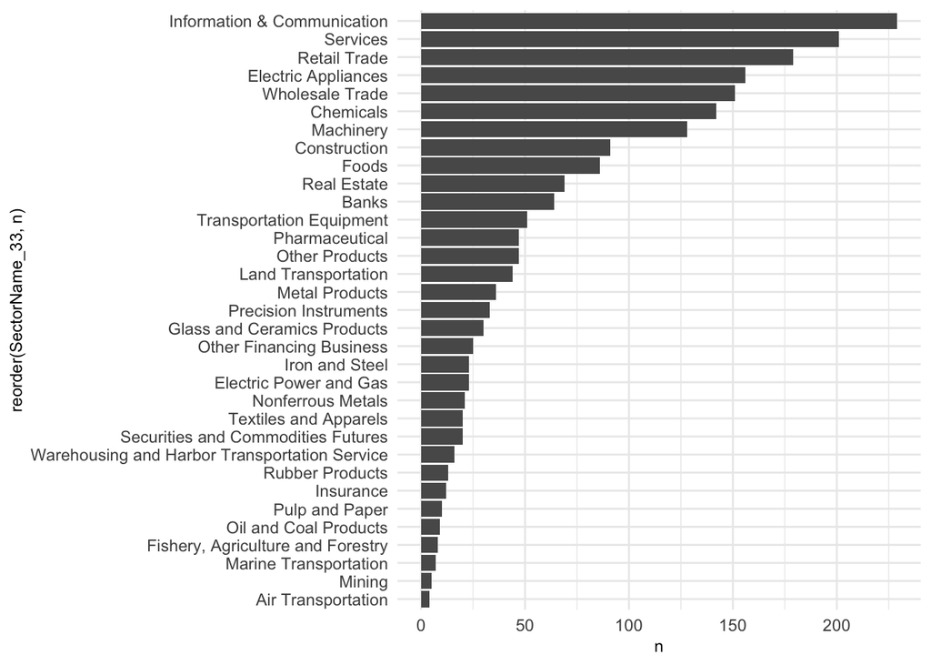

```r
df_stock_price_sector %>%
  ggplot()+
  geom_bar(
    aes(x = reorder(SectorName_33, n), y = n),
    stat = "identity"
  )+
  coord_capped_flip()
```